# Ogólne statystyki

Celem naszej prezentacji była analiza posów a dokładniej rzeczowników na Facebookowej stronie Alior Banku SA.

W otrzymanych danych było w sumie 15594 różnych postów, w tym 5032 napisane przez pracowników banku. W komentarzach znajdowało się 10824 różnych rzeczowników, a w sumie 114447 rzeczowników.

# PUNKT WIDZENIA - GRUPY NADAWCÓW

W tym punkcie dokonując analizy rzeczowników w komentarzach Alior Banku zostały dodatkowo usunięte imiona i nazwiska (bądź wymyślone nazwy) adresatów postów. Aktywny udział (więcej niż 1 komentarz) brało 4645 różnych użytkowników. Przedstawimy teraz kilka statystyk dotyczących pracowników banku oraz 3 najaktywniejszych osób: Łukasz Majewski, Tomasz Ziółkowski i Paweł Krawiec.

[output not shown]

Na poniższym wykresie przedstawiliśmy rozkład sumy rzeczowników z podziałem na lata u trzech najaktywniejszych użytkowników.

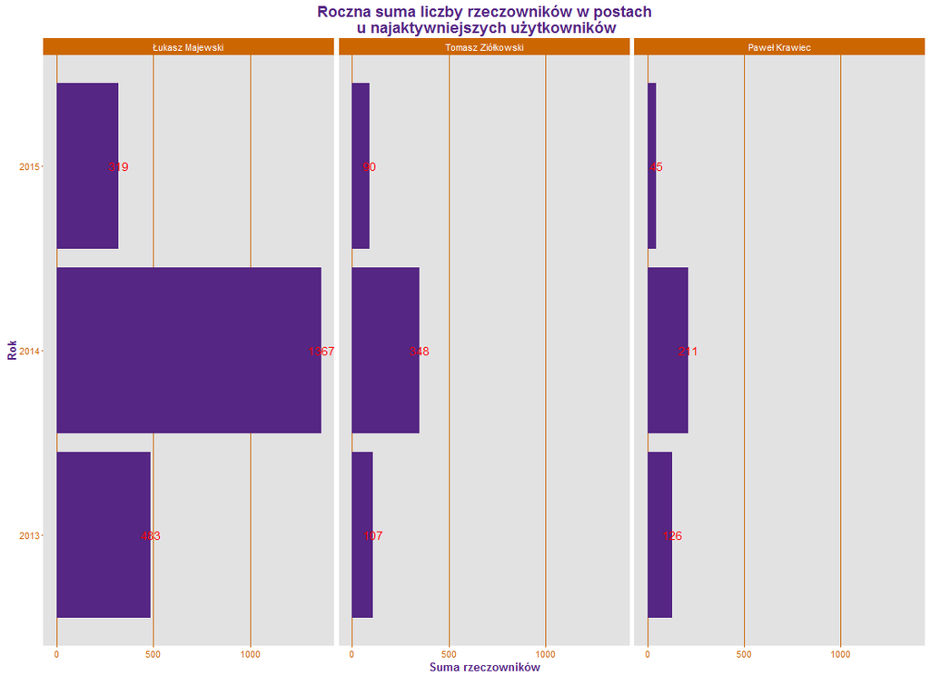

Możemy zaobserwować, że u wszystkich użytkowników najwięcej rzeczowników było w komentarzy w 2014 roku. Widać również skrajne różnice w sumie rzeczowników między nadawcami, ale procentowy udział w 2014 Majewski - 63%, Ziółkowski - 64%, Krawiec - 54% jest podobny. Wszyscy panowie nie pisali już komentarzy w 2016 roku.

Przyjrzyjmy się teraz jakie rzeczowniki powtarzały się najczęściej w komentarzach użytkowników i Alior Banku.

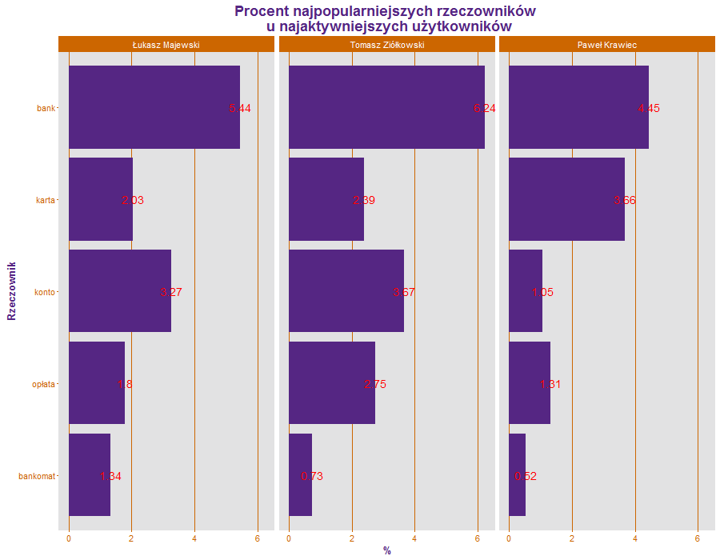

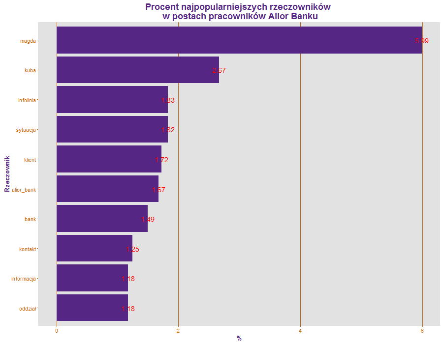